# Tarea3 - Informe

Leonardo Santella | Simon Saman | Eloy Toro

Monday, July 27, 2015

Se nos provee un conjunto de datos a analizar, asociados con la calidad de servicio en un supermercado con la posibilidad de identificar conglomerados dentro de los clientes encuestados. sobre los grupos identificados se espera tener conocimiento para propiciar la elaboracion de politicas de atencion al cliente y otras estrategias de marketing.

A continuacion se tienen las actividades a realizar, seguidamente, su accion.

1. Haga un análisis exploratorio sobre los datos de entrada y determine si es necesaria la aplicación de algún preprocesamiento o limpieza de datos.

```r
#Cargamos las librerias a utilizar
library(FactoMineR)
library(rattle)
#Cargamos los datos
setwd("~/Data Science/Tarea3")

#Lectura de los datos
data <- read.csv("Servicio_al_cliente.csv", header=TRUE, row.names=1, dec=",", sep=";")

#Informacion acerca de los datos
summary(data)
```

```
##       Edad         Antiguedad    Espacios.parqueo Velocidad.Cajas
##  Min.   :19.00   Min.   : 0.00   Min.   :3.400    Min.   :3.200
##  1st Qu.:24.00   1st Qu.: 1.00   1st Qu.:5.600    1st Qu.:7.600
##  Median :27.00   Median : 4.00   Median :6.200    Median :7.800
##  Mean   :28.81   Mean   : 3.27   Mean   :6.119    Mean   :7.897
##  3rd Qu.:32.00   3rd Qu.: 5.00   3rd Qu.:6.800    3rd Qu.:8.600
##  Max.   :49.00   Max.   :13.00   Max.   :8.000    Max.   :9.600
##  DistribuciÃ³n.Productos AtenciÃ³n.Empleados Calidad.Instalaciones
##  Min.   :1.200           Min.   : 7.700      Min.   :0.700
##  1st Qu.:5.000           1st Qu.: 9.300      1st Qu.:2.300
##  Median :7.200           Median :10.000      Median :3.300
##  Mean   :6.535           Mean   : 9.643      Mean   :3.381
##  3rd Qu.:8.200           3rd Qu.:10.000      3rd Qu.:5.000
##  Max.   :9.600           Max.   :10.000      Max.   :6.700
##    UbicaciÃ³n      Limpieza     Variedad.Productos Prestigio.Empresa
##  Min.   : 6.8   Min.   :1.400   Min.   :4.000      Min.   :2.600
##  1st Qu.: 8.6   1st Qu.:6.000   1st Qu.:6.200      1st Qu.:5.800
##  Median : 9.2   Median :6.800   Median :6.600      Median :7.400
##  Mean   : 9.0   Mean   :6.686   Mean   :6.849      Mean   :7.076
##  3rd Qu.: 9.6   3rd Qu.:7.800   3rd Qu.:7.600      3rd Qu.:8.400
##  Max.   :10.0   Max.   :9.600   Max.   :9.400      Max.   :9.800
##  Calidad.Servicio
##  Min.   :1.500
##  1st Qu.:3.900
##  Median :5.400
##  Mean   :5.108
##  3rd Qu.:6.500
##  Max.   :8.800
```

```r
#Dimensiones del data frame obtenido
dim(data)
```

```
## [1] 37 12
```

```r
#Matriz de correlacion de las variables
cor(data)
```

```
##                                Edad   Antiguedad Espacios.parqueo
## Edad                     1.00000000  0.488799985       0.17006495
## Antiguedad               0.48879999  1.000000000       0.14527487
## Espacios.parqueo         0.17006495  0.145274867       1.00000000
## Velocidad.Cajas         -0.42785946 -0.137215708      -0.17736628
## DistribuciÃ³n.Productos -0.49238338 -0.120825896       0.15438181
## AtenciÃ³n.Empleados      0.18240796  0.058419391      -0.02742435
## Calidad.Instalaciones   -0.03730538  0.010256633       0.47257534
## UbicaciÃ³n              -0.05226737 -0.194584529      -0.33604104
## Limpieza                -0.39588964 -0.119673044       0.21578348
## Variedad.Productos      -0.33485883  0.009297402       0.36254087
## Prestigio.Empresa       -0.30881309 -0.144656974       0.30174273
## Calidad.Servicio        -0.14793476 -0.032800960       0.15940841
##                         Velocidad.Cajas DistribuciÃ³n.Productos
## Edad                       -0.427859455             -0.49238338
## Antiguedad                 -0.137215708             -0.12082590
## Espacios.parqueo           -0.177366278              0.15438181
## Velocidad.Cajas             1.000000000              0.43990549
## DistribuciÃ³n.Productos     0.439905488              1.00000000
## AtenciÃ³n.Empleados        -0.307192045             -0.13925668
## Calidad.Instalaciones       0.017073425              0.35761607
## UbicaciÃ³n                  0.058703374              0.04470392
## Limpieza                    0.449525406              0.43741209
## Variedad.Productos          0.231593379              0.38287065
## Prestigio.Empresa           0.348764244              0.48566894
## Calidad.Servicio            0.008563356              0.16576459
##                         AtenciÃ³n.Empleados Calidad.Instalaciones
## Edad                             0.18240796           -0.03730538
## Antiguedad                       0.05841939            0.01025663
## Espacios.parqueo                -0.02742435            0.47257534
## Velocidad.Cajas                 -0.30719205            0.01707342
## DistribuciÃ³n.Productos         -0.13925668            0.35761607
## AtenciÃ³n.Empleados              1.00000000            0.13716594
## Calidad.Instalaciones            0.13716594            1.00000000
## UbicaciÃ³n                       0.10249282           -0.19081017
## Limpieza                        -0.05637057            0.05016600
## Variedad.Productos              -0.12002731            0.29708986
## Prestigio.Empresa               -0.08266032            0.25693688
## Calidad.Servicio                -0.06843872           -0.11156107
##                           UbicaciÃ³n     Limpieza Variedad.Productos
```

[output cut: 10 more lines]

```
## Prestigio.Empresa        0.157153281  0.633712737        0.650413860
## Calidad.Servicio         0.056390216  0.094515291        0.035846452
##                         Prestigio.Empresa Calidad.Servicio
## Edad                          -0.30881309     -0.147934756
## Antiguedad                    -0.14465697     -0.032800960
## Espacios.parqueo               0.30174273      0.159408412
## Velocidad.Cajas                0.34876424      0.008563356
## DistribuciÃ³n.Productos        0.48566894      0.165764593
## AtenciÃ³n.Empleados           -0.08266032     -0.068438718
## Calidad.Instalaciones          0.25693688     -0.111561066
## UbicaciÃ³n                     0.15715328      0.056390216
## Limpieza                       0.63371274      0.094515291
## Variedad.Productos             0.65041386      0.035846452
## Prestigio.Empresa              1.00000000      0.175584126
## Calidad.Servicio               0.17558413      1.000000000
```

Al observar los resultados del analisis previo de los datos, no se obtuvo suficiente evidencia pertinente para eliminar variables poco relevantes para el estudio posterior. Todas las variables se encuentran en un formato numerico, facil de manipular.

2. Aplique el método de componentes principales al conjunto de datos de entrada y, sobre las componentes 1 y 2 realice lo siguiente:
1. Grafique el mapa el círculo de correlaciones y realize un análisis de las relaciones entre las variables involucradas.

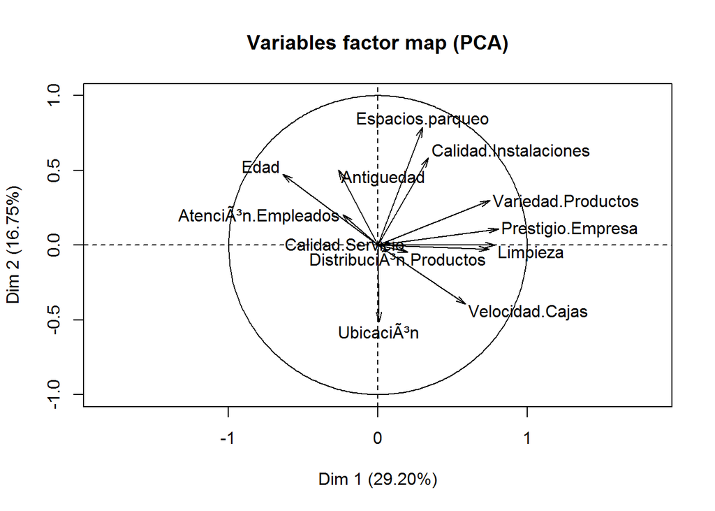

```r
#Analisis de componentes principales
componentes <- PCA(data, graph=FALSE)

#Grafico del circulo de correlaciones, sobre las 2 componentes principales
plot(componentes, axes=c(1,2), choix="var", new.plot=TRUE)
```

2. Grafique el plano principal e identifique la cantidad de posibles grupos.

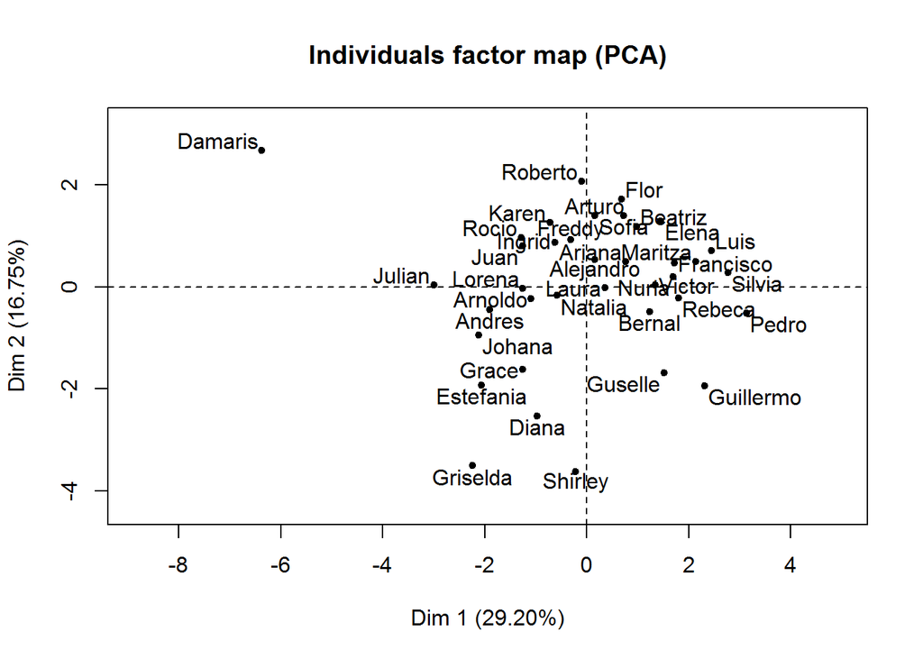

```r
#Grafico del circulo de correlaciones, sobre las 2 componentes principales
plot(componentes, axes=c(1,2), choix="ind", new.plot=TRUE)
```

En general, es dificil identificar un numero optimo de conglomerados. Este caso, no es la excepcion, los individuos estan bastante amontonados en el invervalo [-4,4] para el eje de las abscisas y [-4,2] para el eje de las ordenadas. Se puede observar que el individuo “Damaris” esta alejado de los demas individuos.

Sin tomar en cuenta la dificultad de elegir un numero de conglomerados en este caso, diremos que existen 4 grupos o conglomerados posibles.

2. Características más resaltantes del grupo.

El grupo 1 esta conformado en su mayoria por personas que poseen una edad por encima de los 30 anhos, otra caracteristica resaltante de este grupo es que no estan muy de acuerdo con la velocidad de las cajas de este supermercado.

El grupo 2 esta conformado por personas que en general no tienen un nivel de aprobacion acerca de la calidad de instalaciones, el espacio de parque y la calidad del servicio.

El grupo 3 esta conformado por personas que estan sumamente de acuerdo con la velocidad de las cajas en este supermercado.

4. Determine el grado de representación de los individuos y de las variables y razone sobre si es necesario estudiar otras combinaciones de componentes (por ejemplo 1 y 3 ó 2 y 3)

```r
#Porcentaje de la suma de cosenos cuadrados de los componentes principales 1 y 2 para determinar el grado de representacion de los individuos y las variables sobre estos planos.
ind <- (componentes$ind$cos2[, 1] + componentes$ind$cos2[, 2]) * 100
ind
```

```
##    Ariana   Guselle Francisco  Griselda   Damaris    Johana    Bernal
## 14.328015 56.453084 22.340133 71.698082 91.292941 49.652734 34.416536
##    Freddy Estefania     Laura   Arnoldo   Beatriz    Rebeca     Sofia
## 10.904032 63.387326  1.099575  6.654904 20.022333 39.348565 32.954200
##    Ingrid     Rocio     Karen      Luis     Pedro    Lorena     Elena
## 20.560584 26.815353 38.120604 42.099868 75.482549 34.206822 59.597329
##    Julian   Natalia   Shirley    Andres Alejandro     Grace     Nuria
## 63.734795  2.517039 47.689567 47.164655  5.804482 44.238669 29.763926
##      Flor   Roberto    Victor    Arturo   Maritza     Diana      Juan
## 32.212962 40.014149 33.839927 26.507278 59.652830 53.068172 15.444379
## Guillermo    Silvia
## 82.969907 65.903655
```

```r
var <- (componentes$var$cos2[, 1] + componentes$var$cos2[, 2]) * 100
var
```

```
##                    Edad              Antiguedad        Espacios.parqueo
##               62.841702               32.412173               71.186834
##         Velocidad.Cajas DistribuciÃ³n.Productos     AtenciÃ³n.Empleados
##               50.100182               55.275186                9.689245
##   Calidad.Instalaciones              UbicaciÃ³n                Limpieza
##               45.879667               26.461444               61.522982
##      Variedad.Productos       Prestigio.Empresa        Calidad.Servicio
##               65.652881               66.242118                4.201413
```

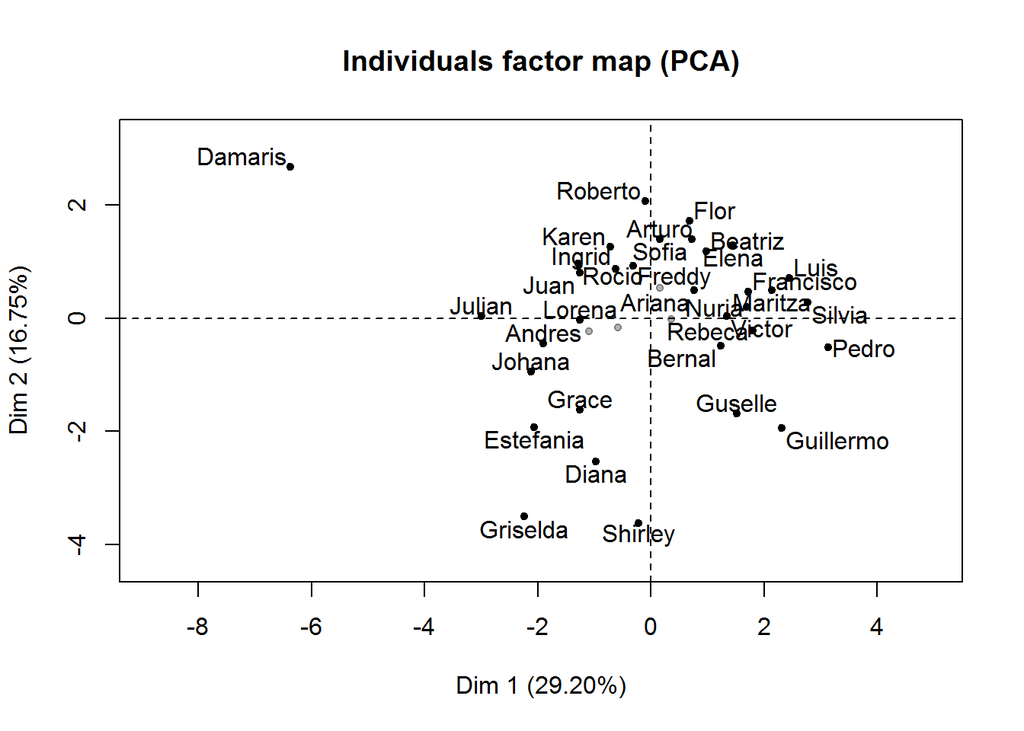

```r
#Grafica de los individuos que tengan cos>=0.5
plot(componentes, axes=c(1,2), choix="ind", new.plot=TRUE, select="cos2 0.1")
```

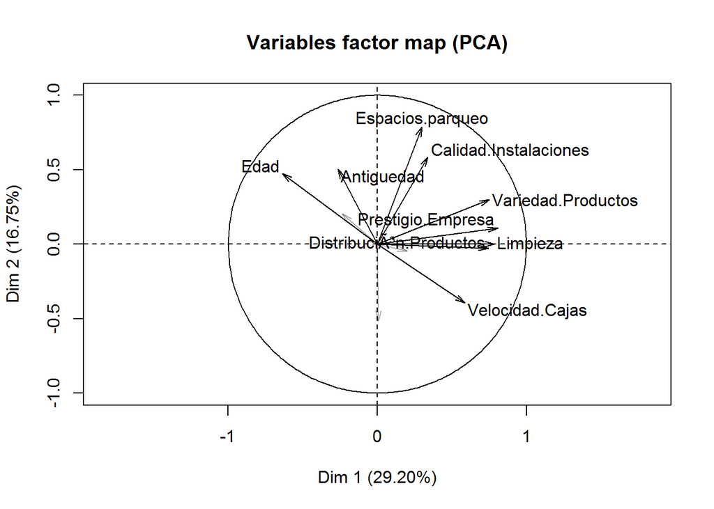

```r
#Grafica de las variables que tengan cos>=0.5
plot(componentes, axes=c(1,2), choix="var", new.plot=TRUE, select="cos2 0.3")
```

Como se puede apreciar, solo fueron dibujados los individuos que tienen un valor de coseno cuadrado mayor o igual a 0.1, siendo este un valor de referencia para identificar individuos que estan muy cerca del origen. Es importante destacar que solo unos pocos estan mal representados.

Al igual que los individuos, las variables que fueron graficadas, son aquellas que tienen un valor de coseno cuadrado mayor que 0.3. Atencion.empleados, Ubicacion y Calidad de servicio son las variables que no estan del todo bien representadas (valor de coseno cuadrado menor a 0.3)

Si las variables antes indicadas, son bastante determinantes, entonces se procederia a encontrar el plano en el cual esten representadas la mayoria de variables altamente determinantes para el estudio, incluyendo las anteriormente mal representadas. Lo mismo pasa con los individuos.

3. Sobre las dos primeras componentes realice un método de clustering para determinar los grupos identificados antes.

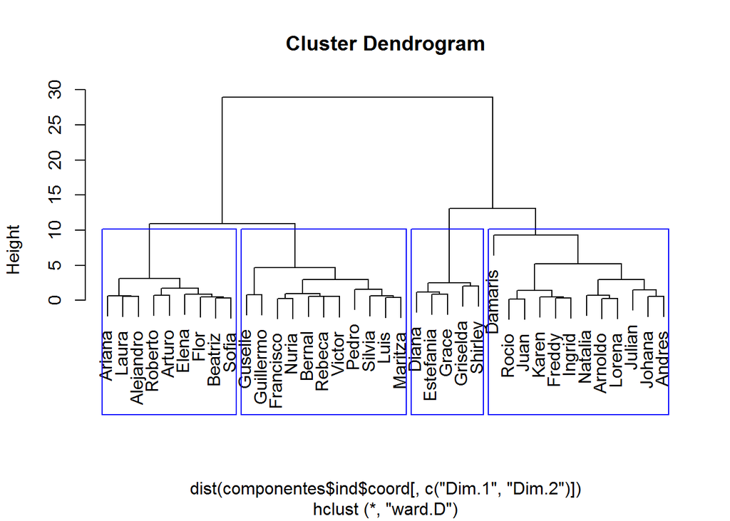

```r
modelo = hclust(dist(componentes$ind$coord[,c("Dim.1", "Dim.2")]), method="ward.D")
plot(modelo)
rect.hclust(modelo, k = 4, border="blue")
```

Como se puede observar, los grupos antes descritos a grandes rasgos, se aproximan a los resultados de aplicar el metodo de clasificacion jerarquica.

4. Agregue el grupo correspondiente a cada cliente como una nueva columna en los datos de entrada y almacene este nuevo data-frame en un archivo llamado Servicio_al_cliente_sal.csv.

```r
grupos <- cutree(modelo, k = 4)
data$Grupo <- grupos
write.csv(x=data, file="Servicio_al_cliente_sal.csv",row.names=TRUE )
```

5. Realice una gráfica de los grupos generados según el método que haya sido empleado para su generación.

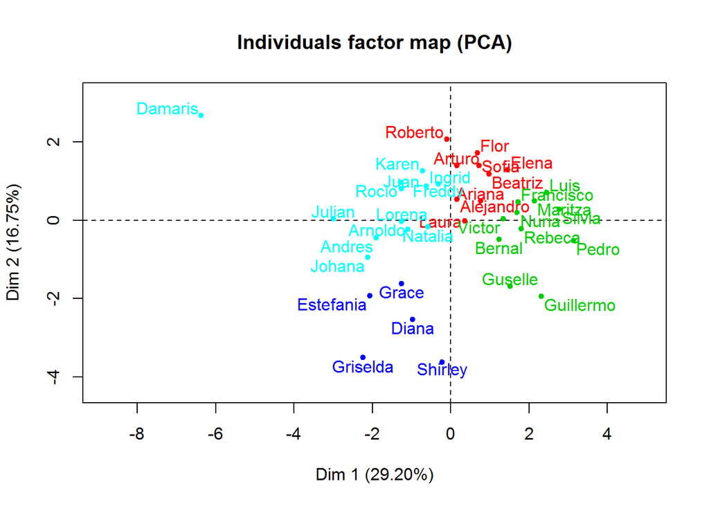

```r
plot(componentes, axes=c(1,2), choix="ind", new.plot=TRUE, col.ind = data$Grupo + 1)
points(data, col = data$Grupo + 1, pch = 19)
```

Al realizar el estudio anterior, se obtuvieron los datos necesarios para tomar en cuenta las siguientes inferencias.

El grupo de color rojo, esta compuesto por individuos que estan de acuerdo con la mayoria de los servicios brindados, algunos no estan del todo de acuerdo con la velocidad en las cajas. Una campana de marketing prudente, seria aquella que refuerce aspectos relevantes en los servicios en cuestion.

El grupo de color verde, a diferencia del grupo de color rojo, esta compuesto por personas jovenes, que estan sumamente de acuerdo con la velocidad de las cajas, como tambien con otros aspectos acerca del servicio y calidad del supermercado.

El grupo representado por el color azul, esta compuesto por individuos que no estan muy de acuerdo con algunos servicios del supermercado, para solucionar este problema, podria utilizarse una campana de marketing en la que estos usuarios se vean beneficiados de alguna manera, ya sea a traves de una oferta o una ventaja por alguna caracteristica inherente a su grupo.